# Populations and Linear Models

Quantitative Analysis of Vertebrate Populations  
Fall 2017

### What is a population?

### What is a population?

- Individuals of a single species
- Potential interbreeding
- Living in the same place and time

### What do we want to know about populations?

### What do we want to know about populations?

- How many individuals (abundance)
- How tightly packed (density)
- Spatial extent (distribution)
- Changes over time (temporal pop dynamics)
- How affected by the each other, other spp., the environment
- Genetic diversity and relatedness of individuals
- Adaptation to the local environment

### What types of data do we collect to learn about populations?

### What types of data do we collect to learn about populations?

- Observations of species presence/absence
- Counts of individuals
- Observations of individuals (Mark-Recapture)
- Movements among populations/sub-populations
- Population genetics
- Correlations and responses to the environment

### A step back: linear models (regression)

Before we can deal with counts or even presence/absence data, it is helpful to understand how linear regression works in the simplest of cases.

Linear Model (LM)

- LM: Continuous response variable \( [-\infty, \infty] \)
- Assume normal error distribution

Generalized Linear Model (GLM)

- Counts and P/A
- Use distributions besides normal

### One more step back: statistical models

response = deterministic part + stochastic part

- deterministic:
- stochastic:

### One more step back: statistical models

response = deterministic part + stochastic part

- deterministic: systematic or mechanistic part of the model (e.g. equation of a line or curve)
- stochastic: random, unexplained part of the model (error distribution)

The stochastic part changes it from just a mathematical model to a statistical model

### Linear Model

Used to describe, and ideally predict, the relationship between variables and the amount of variation explained by the independent variables (deterministic part)

- Dependent variable = response variable (often \( Y \))
- Independent variable = predictor, covariate (often \( X_1, X_2, etc. \))

### Linear model

response = deterministic part + stochastic part

response variable = model + error

\( Y = \beta_0 + \beta_1 X_1 + \beta_2 X_2 \) (error distribution often stated or implied)

\( y_i = \beta_0 + \beta_1 soil_i + \beta_2 litter_i + \epsilon_i \)

### Linear model

\( y_i = \beta_0 + \beta_1 soil_i + \beta_2 litter_i + \epsilon_i \)

\( \epsilon_i \sim \mathcal{N}(\mu, \sigma) \)

The data, \( y_i \), don't have to be normally distributed by the error (residuals) do.

### Normal (Gaussian) distribution

\( \epsilon_i \sim \mathcal{N}(\mu, \sigma) \)

\( \sim \) : distributed as

\( \mu \) : mean

\( \sigma \) : standard deviation

\( \sigma^2 \) : variance

Can see normal distribution expressed in terms of the variance or standard deviation

### Normal (Gaussian) distribution

### Probability density function

\[ F(x | \mu, \sigma) = \frac{1}{{\sigma \sqrt {2\pi } }}e^{{{ - \left( {x - \mu } \right)^2 } \mathord{\left/ {\vphantom {{ - \left( {x - \mu } \right)^2 } {2\sigma ^2 }}} \right.} {2\sigma ^2 }}} \]

### Shorthand

\( \epsilon_i \sim \mathcal{N}(\mu, \sigma) \)

### Normal (Gaussian) distribution

\( \epsilon_i \sim \mathcal{N}(\mu, \sigma) \)

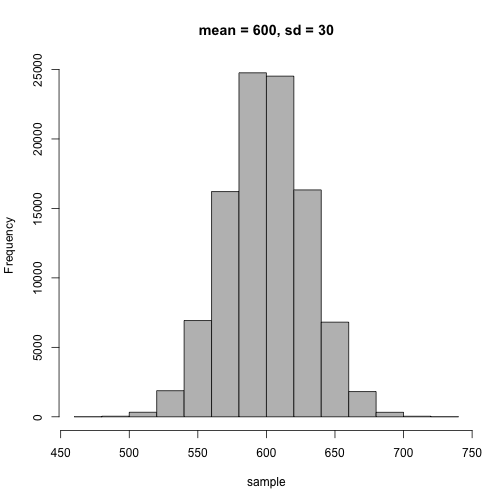

### Other data and distributions?

### Other data and distributions?

More next week

You can bring your laptop to lab if you'd rather use that than the computers in the room.